# Growth-Promoting Fungi Statistical Re-evaluation

Carolina Juncá, Riyad Hilal and Ignacio Romero

18/01/2021

## Introduction

In typically intensive crops like bean, maize or soybean are able to reach high yields thanks to the abusive use of pesticides and fertilizers. In an attempt to manage agriculture in a more sustainable way, Noemi Carla Baron , Andressa de Souza Pollo and Everlon Cid Rigobelo in their article [" Purpureocillium lilacinum and Metarhizium marquandii as plant growth-promoting fungi."](https://peerj.com/articles/9005/) test the performance of *Purpureocillium lilacinum, Purpureocillium lavendulum* and *Metarhizium marquandii* as potential bioinoculants that might replace the current products.

In order to do so, Baron et al. isolated the strains used from soil samples. All the different strains where screened for their ability to solubilize phosphorus (P) and produce indolacetic acid (IAA). Those who were more promising were tested in greenhouse inoculation experiments, where Growth promotion parameters including plant height, dry mass and contents of P and nitrogen (N) in the plants and in the rhizospheric soil were assessed. As statistical analysis software AGROESTAT was used.

In this project, the results obtained by the authors is reanalyzed and reformulated using RStudio and different packages that allow to carry out any analysis and display the output in a more convenient way.

The packages used are the next:

```r
#install.packages("agricolae")
library(agricolae)
#install.packages("lmtest")
library(lmtest)
#install.packages("ggplot2")
library(ggplot2)
#install.packages("rstatix")
library (rstatix)
#install.packages("nortest")
library (nortest)
#install.packages("BBmisc")
library(BBmisc)
# install.packages("dplyr")
library(dplyr)
# install.packages("readxl")
library(readxl)
# install.packages("tidyr")
library(tidyr)
#install.packages("kableExtra")
library(kableExtra)
#install.packages("tidyverse")
library(tidyverse)
#install.packages('factoextra')
library(factoextra)
#install.packages('MASS')
library("MASS")
```

## Objectives

1. Select which of the strains provided are the most promising to test in greenhouse experiment according to their P solubilization and IAA production.
2. Carry out a Principal Component Analysis (PCA) and a Linear Discriminant Analysis (LDA) to characterize the data obtained from the greenhouse experiment.

3.Evaluate the performance of the strains selected by the authors by doing statistical analysis using the data provided.

## Data preparation

First of all, working in RStudio requires the importation of the data to the working environment and its shaping into a suitable data frame that allows its management and the utilization of the different tools that the software provides.

The code for the importation creates a folder called “Data” where tables with raw data will be downloaded directly from the original article.

```r
#Creating the folder "Data" if it doesn't exist
D <- "Data"
if (!dir.exists(D)) dir.create(D)

#Bacteria IAA and P concentrations
xl_1 <- "https://dfzljdn9uc3pi.cloudfront.net/2020/9005/1/DatasetS1_Raw_Data__Screening__P_solubilization_and_IAA_production.xlsx"
download.file(xl_1, "Data/Data.xlsx", mode = "wb")

#Green House morphological trait measures
xl_2 <- "https://dfzljdn9uc3pi.cloudfront.net/2020/9005/1/Raw_Data_Greenhouse_tests.xlsx"
download.file(xl_2, "Data/Data_GH.xlsx", mode = "wb")
```

Different organized data frames where created from the raw data. These data frames contain the different strains tested , the repetitions and the biochemical or growth parameters.

```r
#Bacteria IAA and P concentrations

#readxl::excel_sheets("Data/Data.xlsx")  To check the sheet names
D_Phosphorus<- readxl::read_excel("Data/Data.xlsx", sheet = 1)
D_IndolA<- readxl::read_excel("Data/Data.xlsx", sheet = 2)

  #Filling in the LSM strain column
D_Phosphorus <- D_Phosphorus %>%
  fill(`LSM strain`)

D_IndolA <- D_IndolA %>%
  fill(`LSM strain`)

  #Merge the 2 dataframes
IAA_pg <- D_IndolA$`µg AIA/ g biomass`
D_Biochem <- cbind.data.frame(D_Phosphorus, IAA_pg)
names(D_Biochem)[names(D_Biochem) == "IAA_pg"] <- "µg IAA/ g biomass" #rename IAA column

#Green House morphological trait measures

#readxl::excel_sheets("Data/Data_GH.xlsx")
D_Bean <- readxl::read_excel("Data/Data_GH.xlsx", sheet = 1)
D_Maize <- readxl::read_excel("Data/Data_GH.xlsx", sheet = 2)
D_Soy <- readxl::read_excel("Data/Data_GH.xlsx", sheet = 3)

  #Filling in the treatments
D_Bean <- D_Bean %>%
  fill (`Treatments (strains)`)
D_Maize <- D_Maize %>%
  fill (`Treatments (strains)`)
D_Soy <- D_Soy %>%
  fill (`Treatments (strains)`)

  #Adding the crop name column
D_Bean$Cropname <- "Bean"
D_Maize$Cropname <- "Maize"
D_Soy$Cropname <- "Soybean"

  #Eliminate N Soil (%) column from D_Soy
D_Soy <- D_Soy[-which(names(D_Soy) == "N Soil (%)")] # - (eliminate) which column name in D_Soy is N Soil (%) (column 8)

  #Eliminate last two rows
D_Bean <- head(D_Bean, -2)
D_Maize <- head(D_Maize, -2)
D_Soy <- head(D_Soy, -2)

  #Merge the 3 dataframes
D_GH <- union(D_Bean, D_Maize) #check 2 lines between each merged dataframe, union_all for duplicates not to be removed
D_GH <- union(D_GH, D_Soy)
```

Once all the data is shaped and organized the analysis can begin.

## Strain selection method

### Idolacetic acid production:

Some tidying up of the data frame was done in order avoid errors when running the code.

```r
D_IAA <- D_IndolA[-which(names(D_IndolA) == "Repetition")]
names(D_IAA)[names(D_IAA) == "µg AIA/ g biomass"] <- "IAA_pg"
names(D_IAA)[names(D_IAA) == "LSM strain"] <- "LSM_strain"
```

Normality was tested and as seen below, there are significant differences in the production of IAA among the strains:

```r
D_IAA$LSM_strain <- as.factor(D_IAA$LSM_strain)
ANOVA_IAA<- aov (D_IAA$IAA_pg ~ D_IAA$LSM_strain, data= D_IAA)
print(summary(ANOVA_IAA))
```

```
##                  Df    Sum Sq  Mean Sq F value Pr(>F)
## D_IAA$LSM_strain 29 2.615e+09 90162553   24.04 <2e-16 ***
## Residuals        60 2.251e+08  3751355
## ---
## Signif. codes:  0 '***' 0.001 '**' 0.01 '*' 0.05 '.' 0.1 ' ' 1
```

Lillie test Was chosen to do the in order to test the normality because it allows the processing of more than 50 dependent variables at once.

```r
nortest::lillie.test(ANOVA_IAA$residuals)
```

```
##
##  Lilliefors (Kolmogorov-Smirnov) normality test
##
## data:  ANOVA_IAA$residuals
## D = 0.16349, p-value = 3.136e-06
```

Afterwards, homoscedasticity was tested using the Breusch-Pagan test:

```r
lmtest::bptest(ANOVA_IAA)
```

```
##
##  studentized Breusch-Pagan test
##
## data:  ANOVA_IAA
## BP = 58.427, df = 29, p-value = 0.0009652
```

As they were not normal or homeoscedastic, Kruskal-Wallis and Holm analyses were carried out, obtaining the following groups:

```r
kr <- agricolae::kruskal(D_IAA[2], D_IAA[1], alpha = 0.05, p.adj ="holm", group=TRUE)
kr$groups
```

```
##     D_IAA[2]    groups
## 65  89.00000         a
## 62  86.00000        ab
## 68  79.33333       abc
## 179 78.00000      abcd
## 183 76.66667     abcde
## 72  72.00000    abcdef
## 67  68.00000   abcdefg
## 182 61.66667   abcdefg
## 22  60.66667   abcdefg
## 14  57.33333  abcdefgh
## 177 52.66667 abcdefghi
## 19  52.00000  bcdefghi
## 24  51.66667  bcdefghi
## 59  50.66667 bcdefghij
```

[output cut: 16 more lines]

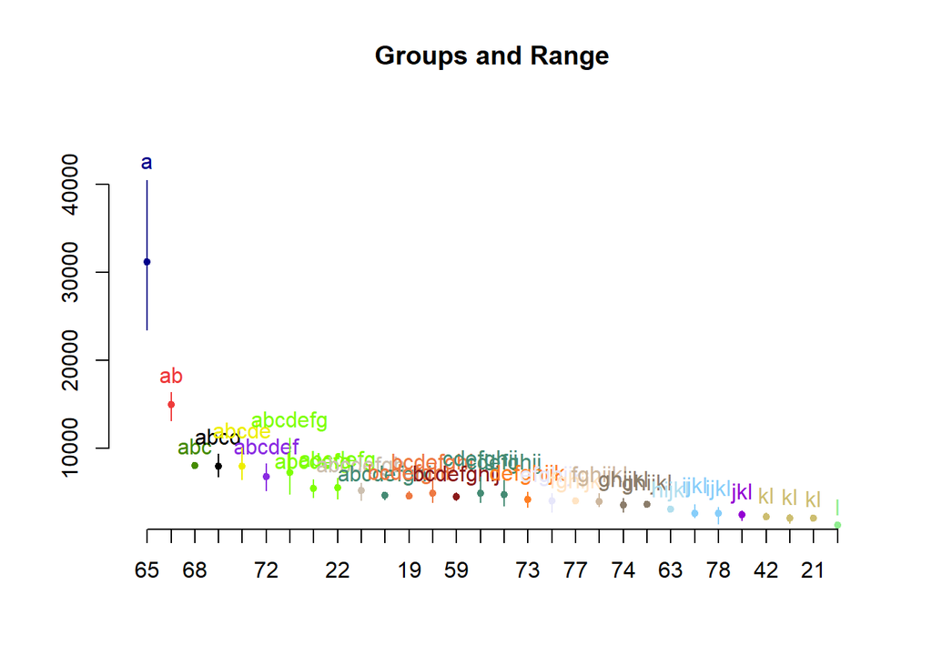

```r
plot (kr)
```

```r
n_IAA <- log(D_IAA$IAA_pg)
n_D_IAA <- data.frame(n_IAA, D_IAA$LSM_strain)
ANOVA_n_IAA<- aov (n_D_IAA$n_IAA ~ n_D_IAA$D_IAA.LSM_strain, data= n_D_IAA)
print(summary(ANOVA_n_IAA))
```

```
##                          Df Sum Sq Mean Sq F value Pr(>F)
## n_D_IAA$D_IAA.LSM_strain 29  33.40  1.1518   22.48 <2e-16 ***
## Residuals                60   3.07  0.0512
## ---
## Signif. codes:  0 '***' 0.001 '**' 0.01 '*' 0.05 '.' 0.1 ' ' 1
```

```r
nortest::lillie.test(ANOVA_n_IAA$residuals)
```

```
##
##  Lilliefors (Kolmogorov-Smirnov) normality test
##
## data:  ANOVA_n_IAA$residuals
## D = 0.05455, p-value = 0.7328
```

```r
lmtest::bptest(ANOVA_n_IAA)
```

```
##
##  studentized Breusch-Pagan test
##
## data:  ANOVA_n_IAA
## BP = 43.249, df = 29, p-value = 0.04317
```

```r
T_nIAA <- HSD.test(ANOVA_n_IAA,'n_D_IAA$D_IAA.LSM_strain', group = TRUE, alpha = 0.05)
T_nIAA$groups
```

```
##     n_D_IAA$n_IAA  groups
## 65      10.321569       a
## 62       9.608631      ab
## 68       8.994972      bc
## 179      8.973114      bc
## 183      8.971110      bc
## 67       8.827616      cd
## 72       8.807638      cd
## 22       8.604640     cde
## 182      8.596952     cde
## 14       8.545482    cdef
## 24       8.483295   cdefg
## 175      8.468843   cdefg
## 177      8.456092   cdefg
## 19       8.434540   cdefg
```

[output cut: 16 more lines]

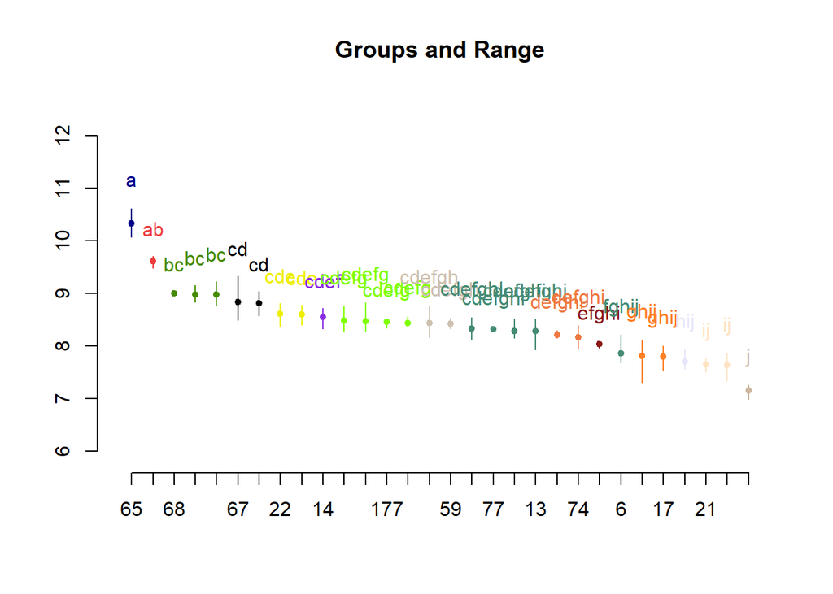

```r
plot(T_nIAA)
```

Also, Duncan test was done, in order to learn if there is some differences with Tukey’s test:

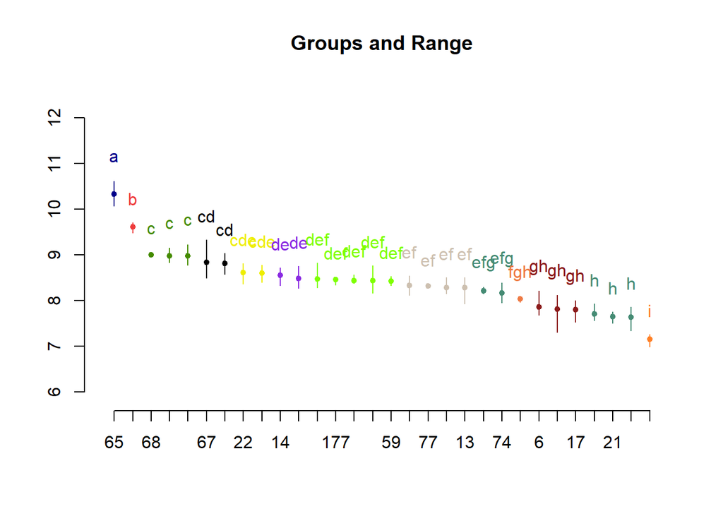

```r
D_nIAA <- duncan.test(ANOVA_n_IAA,'n_D_IAA$D_IAA.LSM_strain')
plot(D_nIAA)
```

As expected, Duncan’s test is more strict when grouping, meaning that considers that two values are not in the same group, when Tukey’s tags them with the same letter.

The analysis results in 5 strains being in the first and second groups, the LSM 65,62,68,179 and 183, being all of them present in the greenhouse experiments.

### Solubilized Phosphorous production:

As done previously some tidying up of the data frame was done in order to avoid errors when running the code.

```r
names(D_Phosphorus)[names(D_Phosphorus) == "µg P/ g biomass"] <- "P_pg" #rename µg P/ g biomass column
names(D_Phosphorus)[names(D_Phosphorus) == "LSM strain"] <- "LSM_strain" #rename LSM strain column
```

The data were tested for normality:

```r
ANOVA_P<- aov (D_Phosphorus$P_pg ~ D_Phosphorus$LSM_strain, data= D_Phosphorus)
print(summary(ANOVA_P))
```

```
##                         Df    Sum Sq   Mean Sq F value   Pr(>F)
## D_Phosphorus$LSM_strain  1 204042255 204042255   22.62 7.65e-06 ***
## Residuals               88 793615247   9018355
## ---
## Signif. codes:  0 '***' 0.001 '**' 0.01 '*' 0.05 '.' 0.1 ' ' 1
```

```r
nortest::lillie.test(ANOVA_P$residuals)
```

```
##
##  Lilliefors (Kolmogorov-Smirnov) normality test
##
## data:  ANOVA_P$residuals
## D = 0.10712, p-value = 0.01259
```

```r
T_P <- HSD.test(ANOVA_P,'D_Phosphorus$LSM_strain', group = TRUE, alpha = 0.05)
T_P$groups
```

```
##     D_Phosphorus$P_pg groups
## 24          16235.357      a
## 14          13581.868     ab
## 65          13043.085     ab
## 6           12616.056     ab
## 59          12588.232     ab
## 19          12406.324     ab
## 62          11296.200     ab
## 63          10363.671     ab
## 17          10094.929     ab
## 22           9977.261     ab
## 13           9068.067     ab
## 20           8931.544     ab
## 21           8906.176     ab
## 42           8795.268     ab
```

[output cut: 16 more lines]

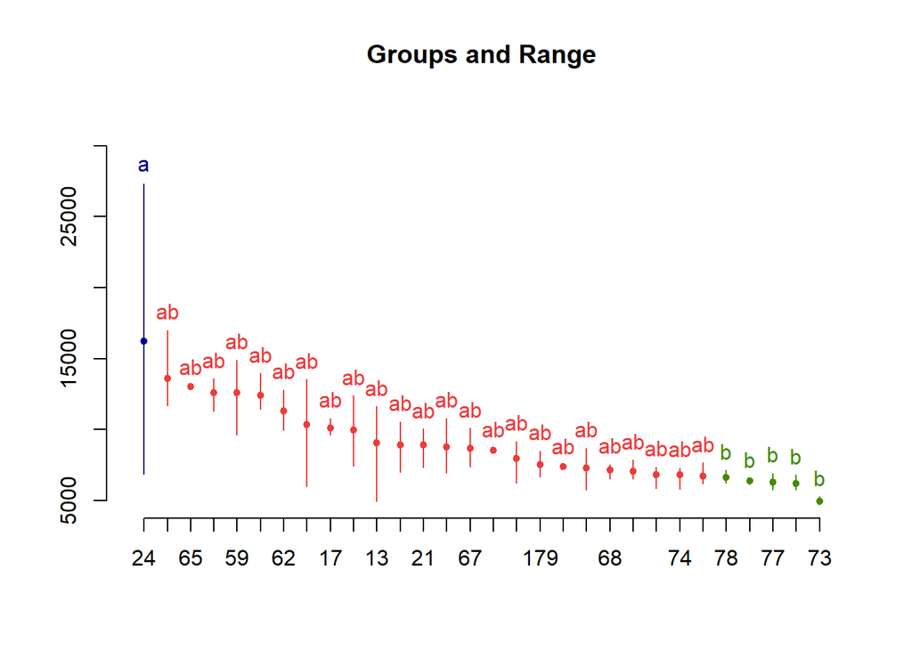

```r
plot(T_P)
```

```r
D_P <- duncan.test(ANOVA_P,'D_Phosphorus$LSM_strain')
D_P$groups
```

```
##     D_Phosphorus$P_pg groups
## 24          16235.357      a
## 14          13581.868     ab
## 65          13043.085    abc
## 6           12616.056   abcd
## 59          12588.232   abcd
## 19          12406.324  abcde
## 62          11296.200 abcdef
## 63          10363.671 bcdefg
## 17          10094.929 bcdefg
## 22           9977.261 bcdefg
## 13           9068.067 bcdefg
## 20           8931.544 bcdefg
## 21           8906.176 bcdefg
## 42           8795.268 bcdefg
```

[output cut: 16 more lines]

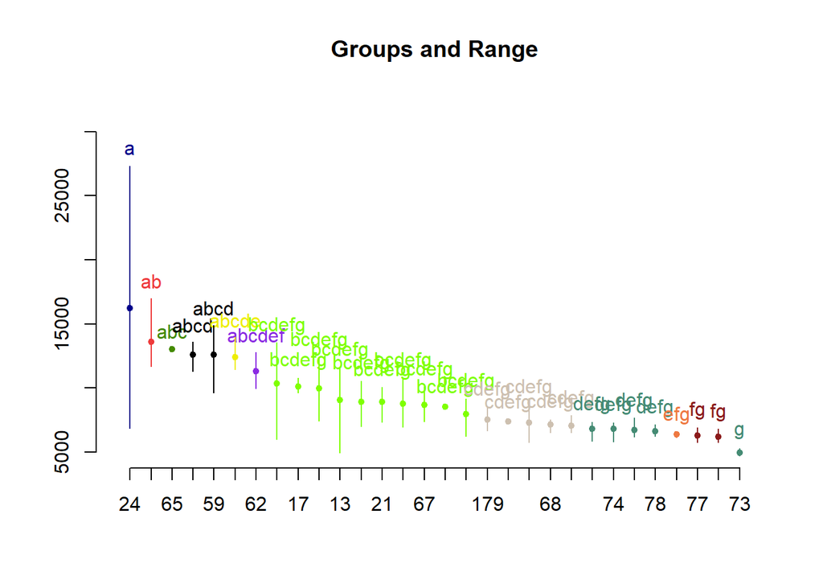

```r
plot(D_P)
```

Additionally, the variance of strain 24 is very big, more repetitions would be needed in order to confidently deem it better than the others. If the upper extreme value is omitted, LSM 24 would belong to the same group as the other strains.

## Strain selection results

As seen above, due to the big amounts of strains that have to be analyzed and compared, is much more useful the Duncan’s test than the Tukey’s. However, the judgment of the authors remains unclear, since the choose 5 strains according to the IAA production and only 3 from solubilized P, despite the uncertainty of this last.

In the end, the strains chosen to be analyzed are the following: **LSM 65, 62, 68, 179, 183, 24 and 14.**

## PCA

Principal Components Analysis was done in order to see if the data groups according to some of the independent variables (crops or strains).

For this project, the package `factoextra` is used to carry out the PCA.

### Crops PCA

PCA differentiated by crops:

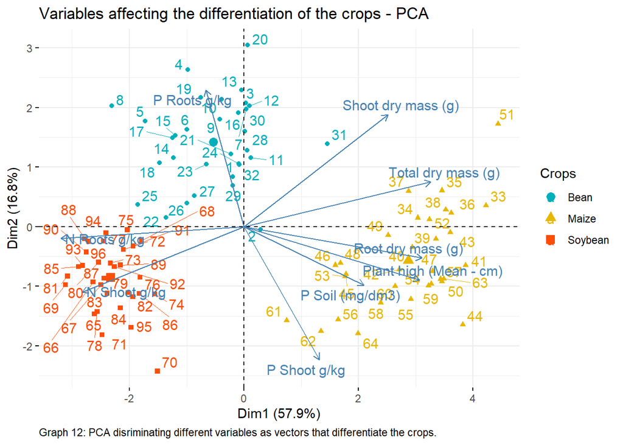

```r
PCAvariables <- factoextra::fviz_pca_biplot(C_pca,
                           col.ind = groups_c,#color by groups
                           palette = c("#00AFBB", "#E7B800", "#FC4E07", "#FF0066"),
                           legend.title = "Crops",
                           repel = TRUE)+
  labs(title= "Variables affecting the differentiation of the crops - PCA",
    caption= "Graph 12: PCA disriminating different variables as vectors that differentiate the crops.")+
  theme(plot.caption = (element_text(hjust = 0)))
PCAvariables
```

```r
#Opposite direction arrows indicate negative correlations between the variables
```

PCA for each crop (dif colors), discriminating treatments with names.

PCA labeled according to the strains, to reveal if there is some grouping by the strains.

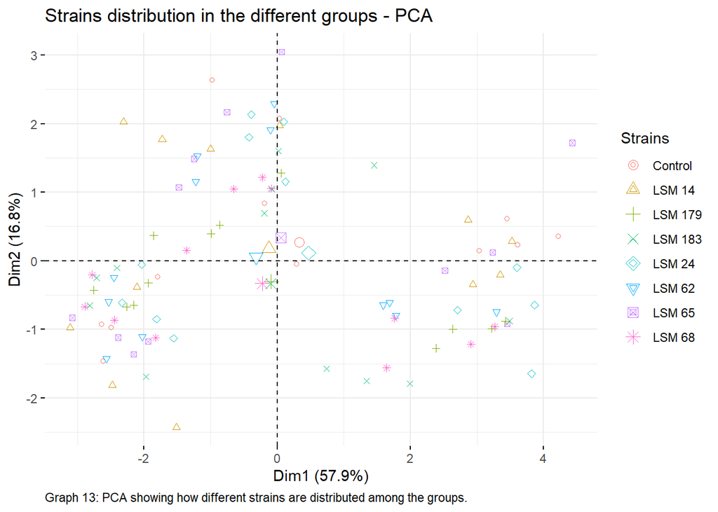

```r
groups_t <- as.factor(D_GH$`Treatments (strains)`)
PCAstrains <- factoextra::fviz_pca_ind(C_pca,geom ="point",
                         col.ind = groups_t, # color by groups
                         #palette = c("#00AFBB", "#E7B800", "#FC4E07", "#FF0066"),
                         #addEllipses = TRUE, # Concentration ellipses
                         #ellipse.type = "confidence",
                         legend.title = "Strains",
                         repel = FALSE)+
  labs(title= "Strains distribution in the different groups - PCA",
    caption= "Graph 13: PCA showing how different strains are distributed among the groups.")+
  theme(plot.caption = (element_text(hjust = 0)))
PCAstrains
```

Since the differentiation is mainly on the crop type, a deeper analysis is done within each crop.

### Bean PCA

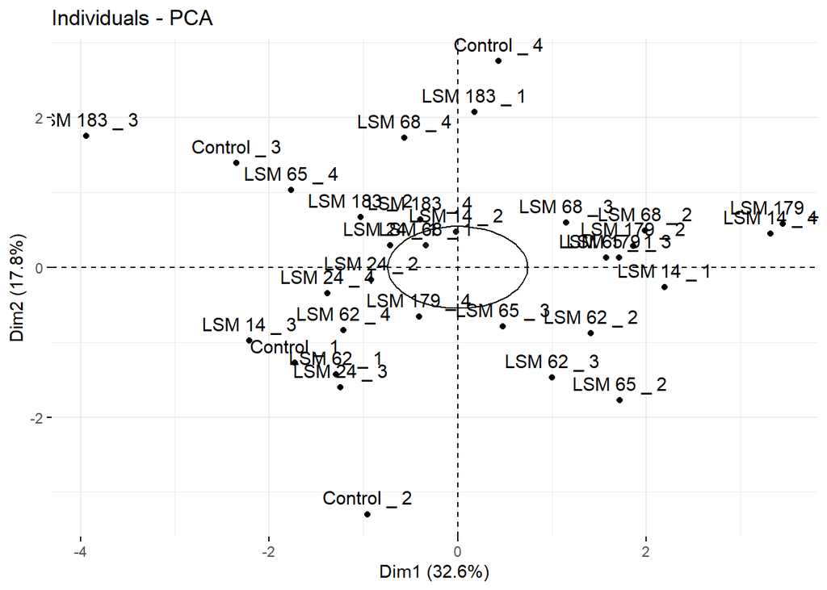

```r
D_GHb<- D_GH[,c(3:13)]
D_GHb <- D_GHb[D_GHb$Cropname == "Bean",]
Name <- D_GHb$Name
D_GHb <- D_GHb [1:9]
rownames(D_GHb)<-Name
B_pca <- prcomp(D_GHb, scale = TRUE)
factoextra::fviz_pca_ind(B_pca,
                         geom = c("point", "text"),
                         #col.ind = groups_t,
                         #palette = c("#00AFBB", "#E7B800", "#FC4E07", "#FF0066"),
                         addEllipses = TRUE, # Concentration ellipses
                         ellipse.type = "confidence",
                         #legend.title = "Treatments",
                         repel = FALSE)
```

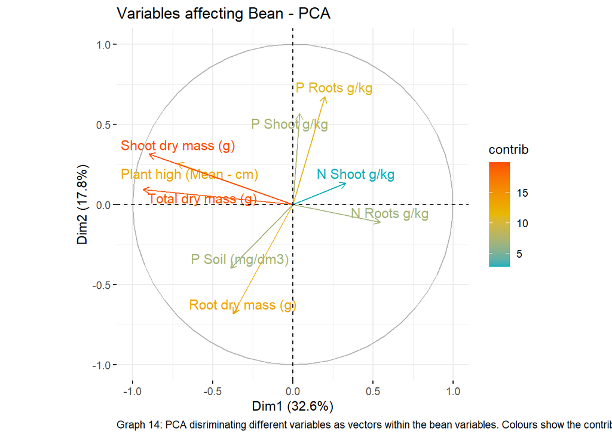

```r
PCAbean <- factoextra::fviz_pca_var(B_pca,
                         col.var = "contrib", # Color by contributions to the PC
                         gradient.cols = c("#00AFBB", "#E7B800", "#FC4E07"),
                         repel = TRUE)+
  labs(title= "Variables affecting Bean - PCA",
    caption= "Graph 14: PCA disriminating different variables as vectors within the bean variables. Colours show the contribution of each variable.")+
  theme(plot.caption = (element_text(hjust = 0)))
PCAbean
```

### Maize PCA

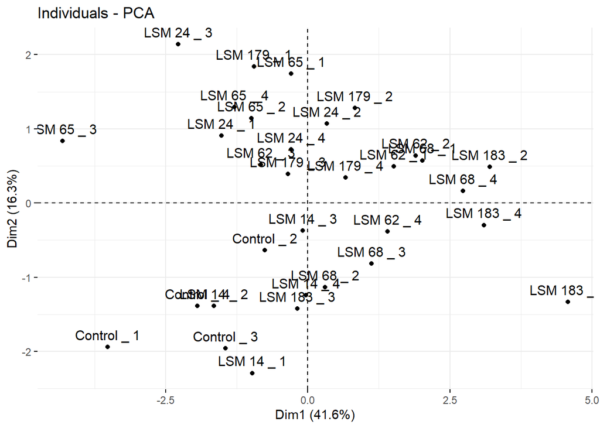

```r
D_GHm<- D_GH[,c(3:13)]
D_GHm <- D_GHm[D_GHm$Cropname == "Maize",]
Name <- D_GHm$Name
D_GHm <- D_GHm [1:9]
rownames(D_GHm)<-Name
M_pca <- prcomp(D_GHm, scale = TRUE)
factoextra::fviz_pca_ind(M_pca,
                         geom = c("point", "text"),
                         #col.ind = groups_t,
                         #palette = c("#00AFBB", "#E7B800", "#FC4E07", "#FF0066"),
                         #addEllipses = TRUE, # Concentration ellipses
                         #ellipse.type = "confidence",
                         #legend.title = "Treatments",
                         repel = FALSE)
```

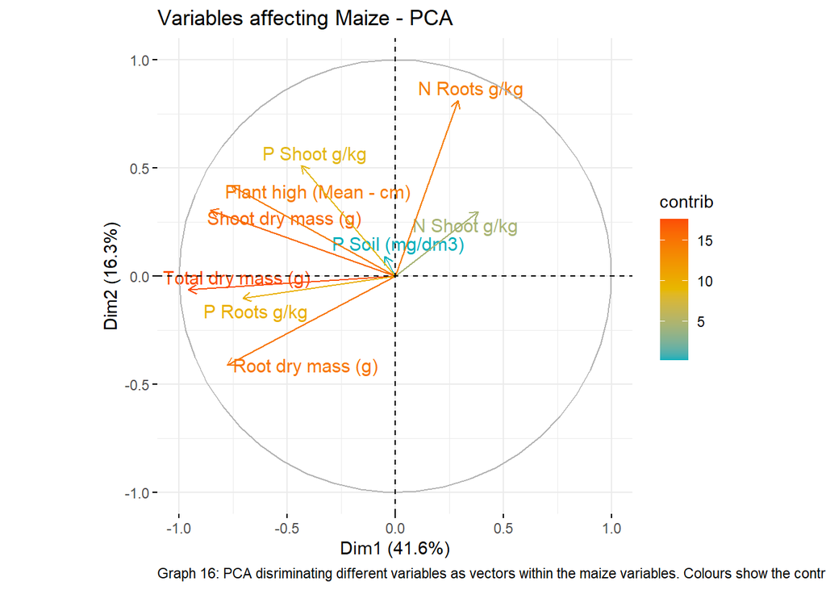

```r
PCAmaize <- factoextra::fviz_pca_var(M_pca,
                         col.var = "contrib", # Color by contributions to the PC
                         gradient.cols = c("#00AFBB", "#E7B800", "#FC4E07"),
                         repel = TRUE)+
  labs(title= "Variables affecting Maize - PCA",
    caption= "Graph 16: PCA disriminating different variables as vectors within the maize variables. Colours show the contribution of each variable.")+
  theme(plot.caption = (element_text(hjust = 0)))
PCAmaize
```

### Soybean PCA

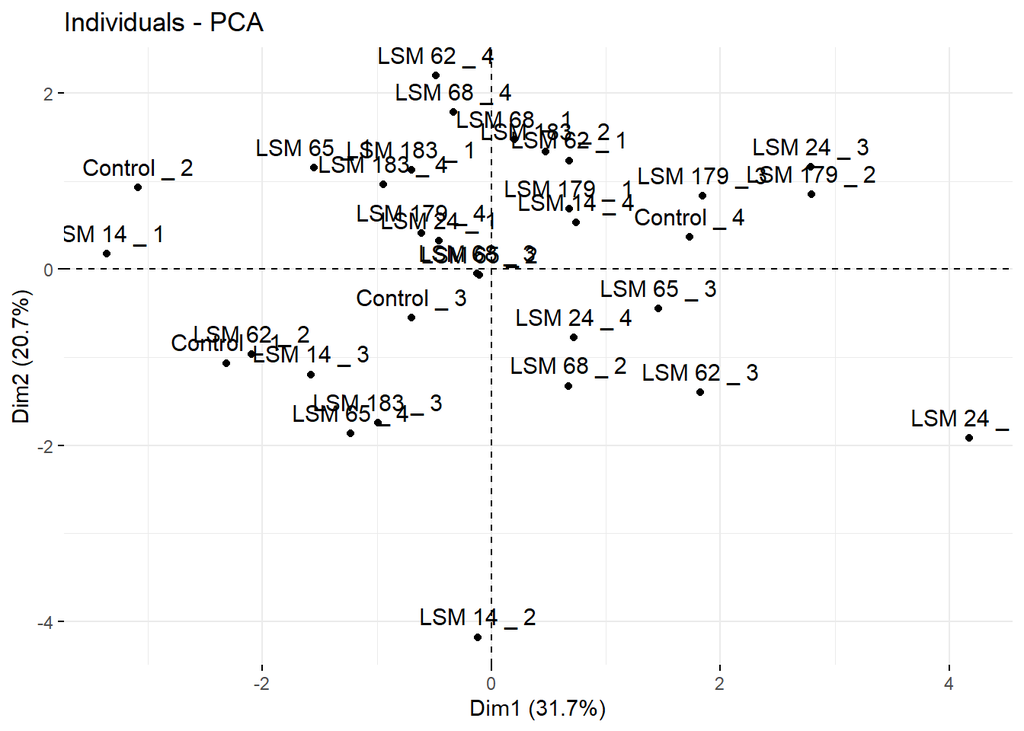

```r
D_GHs<- D_GH[,c(3:13)]
D_GHs<- D_GHs[D_GHs$Cropname == "Soybean",]
Name <- D_GHs$Name
D_GHs <- D_GHs [1:9]
rownames(D_GHs)<-Name
S_pca <- prcomp(D_GHs, scale = TRUE)
factoextra::fviz_pca_ind(S_pca,
                         geom = c("point", "text"),
                         #col.ind = groups_t,
                         #palette = c("#00AFBB", "#E7B800", "#FC4E07", "#FF0066"),
                         #addEllipses = TRUE, # Concentration ellipses
                         #ellipse.type = "confidence",
                         #legend.title = "Treatments",
                         repel = FALSE)
```

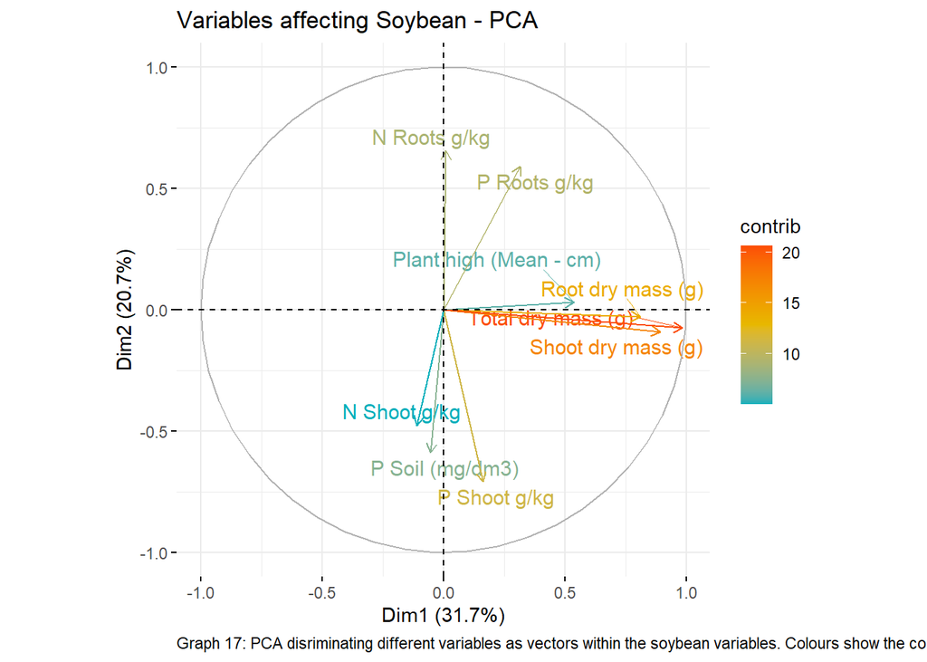

```r
PCAsoy <- factoextra::fviz_pca_var(S_pca,
                         col.var = "contrib", # Color by contributions to the PC
                         gradient.cols = c("#00AFBB", "#E7B800", "#FC4E07"),
                         repel = TRUE)+
  labs(title= "Variables affecting Soybean - PCA",
    caption= "Graph 17: PCA disriminating different variables as vectors within the soybean variables. Colours show the contribution of each variable.")+
  theme(plot.caption = (element_text(hjust = 0)))
PCAsoy
```

```r
Bean.lda <- lda(D_Bean$`Treatments (strains)`~D_Bean$`Plant high (Mean - cm)` +
                  D_Bean$`Shoot dry mass (g)` +
                  D_Bean$`Root dry mass (g)`+
                  D_Bean$`Total dry mass (g)` +
                  D_Bean$`P Soil (mg/dm3)` +
                  D_Bean$`P Shoot g/kg`+
                  D_Bean$`P Roots g/kg` +
                  D_Bean$`N Shoot g/kg` +
                  D_Bean$`N Roots g/kg`
                  )
```

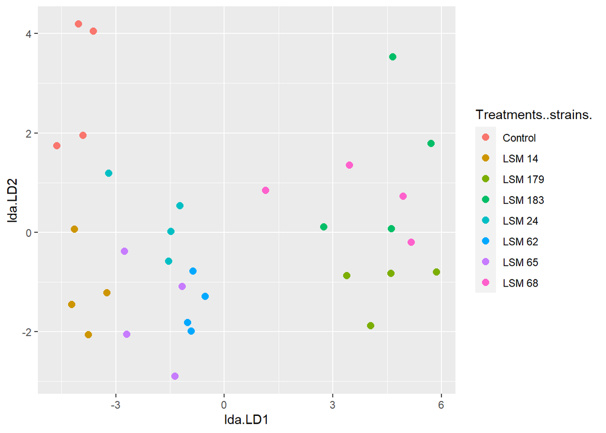

```r
Bean.lda.values <- predict(Bean.lda, D_Bean[3:11])
newdata <- data.frame(type = D_Bean[,1], lda = Bean.lda.values$x)
ggplot(newdata) + geom_point(aes(lda.LD1, lda.LD2, colour = Treatments..strains.), size = 2.5)
```

## Strain re-evaluation method

A similar process has been followed to identify the most optimal strains in the greenhouse experiments. First an ANOVA has been done, taking into account all the different assumptions. Then, for those cases in which ANOVA is not possible, the Kruskal-Wallis’ test has been done. For the rest of the cases, Duncan’s test was carried out to assess the different grouping options.

### ANOVA

The greenhouse results are tested in order to find out the effect of the selected strains. First of all, in order to address significant differences, an ANOVA test has been carried out.

```r
#Anovas for Bean
anovabean3 <- aov(D_Bean[[3]]~D_Bean[[1]], data = D_Bean)
anovabean4 <- aov(D_Bean[[4]]~D_Bean[[1]], data = D_Bean)
anovabean5 <- aov(D_Bean[[5]]~D_Bean[[1]], data = D_Bean)
anovabean6 <- aov(D_Bean[[6]]~D_Bean[[1]], data = D_Bean)
anovabean7 <- aov(D_Bean[[7]]~D_Bean[[1]], data = D_Bean)
anovabean8 <- aov(D_Bean[[8]]~D_Bean[[1]], data = D_Bean)
anovabean9 <- aov(D_Bean[[9]]~D_Bean[[1]], data = D_Bean)
anovabean10 <- aov(D_Bean[[10]]~D_Bean[[1]], data = D_Bean)
anovabean11 <- aov(D_Bean[[11]]~D_Bean[[1]], data = D_Bean)

#Anova for Maize
anovamaize3 <- aov(D_Maize[[3]]~D_Maize[[1]], data = D_Maize)
anovamaize4 <- aov(D_Maize[[4]]~D_Maize[[1]], data = D_Maize)
anovamaize5 <- aov(D_Maize[[5]]~D_Maize[[1]], data = D_Maize)
anovamaize6 <- aov(D_Maize[[6]]~D_Maize[[1]], data = D_Maize)
anovamaize7 <- aov(D_Maize[[7]]~D_Maize[[1]], data = D_Maize)
anovamaize8 <- aov(D_Maize[[8]]~D_Maize[[1]], data = D_Maize)
anovamaize9 <- aov(D_Maize[[9]]~D_Maize[[1]], data = D_Maize)
anovamaize10 <- aov(D_Maize[[10]]~D_Maize[[1]], data = D_Maize)
anovamaize11 <- aov(D_Maize[[11]]~D_Maize[[1]], data = D_Maize)

#Anova for Soy
anovasoy3 <- aov(D_Soy[[3]]~D_Soy[[1]], data = D_Soy)
anovasoy4 <- aov(D_Soy[[4]]~D_Soy[[1]], data = D_Soy)
anovasoy5 <- aov(D_Soy[[5]]~D_Soy[[1]], data = D_Soy)
anovasoy6 <- aov(D_Soy[[6]]~D_Soy[[1]], data = D_Soy)
anovasoy7 <- aov(D_Soy[[7]]~D_Soy[[1]], data = D_Soy)
anovasoy8 <- aov(D_Soy[[8]]~D_Soy[[1]], data = D_Soy)
anovasoy9 <- aov(D_Soy[[9]]~D_Soy[[1]], data = D_Soy)
anovasoy10 <- aov(D_Soy[[10]]~D_Soy[[1]], data = D_Soy)
anovasoy11 <- aov(D_Soy[[11]]~D_Soy[[1]], data = D_Soy)
```

After the ANOVAs are done, the normality is tested, using the Shapiro test:

```r
#shapiro tests Bean
shapiro.test(anovabean3$residuals)
shapiro.test(anovabean4$residuals)
shapiro.test(anovabean5$residuals)
shapiro.test(anovabean6$residuals)
shapiro.test(anovabean7$residuals)
shapiro.test(anovabean8$residuals)
shapiro.test(anovabean9$residuals)
shapiro.test(anovabean10$residuals)
shapiro.test(anovabean11$residuals)

#shapiro test Maize
shapiro.test(anovamaize3$residuals)
shapiro.test(anovamaize4$residuals)
shapiro.test(anovamaize5$residuals)
shapiro.test(anovamaize6$residuals)
shapiro.test(anovamaize7$residuals)
shapiro.test(anovamaize8$residuals)
shapiro.test(anovamaize9$residuals)
shapiro.test(anovamaize10$residuals)
shapiro.test(anovamaize11$residuals)

#shapiro test Soy
shapiro.test(anovasoy3$residuals)
shapiro.test(anovasoy4$residuals)
shapiro.test(anovasoy5$residuals)
shapiro.test(anovasoy6$residuals)
shapiro.test(anovasoy7$residuals)
shapiro.test(anovasoy8$residuals)
shapiro.test(anovasoy9$residuals)
shapiro.test(anovasoy10$residuals)
shapiro.test(anovasoy11$residuals)
```

The homoscedaticity is also a requirement in order to approve the results of the ANOVA. It has been tested using the Breusch-Pagan test:

```r
#This function does not accept the $residuals, but since it takes the whole ANOVA result, it is assumed that the residuals are included in the code.

#BEAN
bptest(anovabean3)
bptest(anovabean4)
bptest(anovabean5)
bptest(anovabean6)
bptest(anovabean7)
bptest(anovabean8)
bptest(anovabean9)
bptest(anovabean10)
bptest(anovabean11)

#MAIZE
bptest(anovamaize3)
bptest(anovamaize4)
bptest(anovamaize5)
bptest(anovamaize6)
bptest(anovamaize7)
bptest(anovamaize8)
bptest(anovamaize9)
bptest(anovamaize10)
bptest(anovamaize11)

#SOY
bptest(anovasoy3)
bptest(anovasoy4)
bptest(anovasoy5)
bptest(anovasoy6)
bptest(anovasoy7)
bptest(anovasoy8)
bptest(anovasoy9)
bptest(anovasoy10)
bptest(anovasoy11)
```

As a summary, the Table 1 shows the results of ANOVA and the normality and homoscedasticity tests:

```r
anovaresult.crop <- rep(c("Bean", "Maize", "Soybean"), each = 9)

anovaresult.variable <- rep(c(names(D_GH[,3:11])), 3)

pvalue.bean <-c("0.0124 *", "0.0788", "0.628", "0.203", "0.061", "9.04e-10 ***", "0.623", "0.0245 *", "0.462")
pvalue.maize <- c("9.53e-07 ***", "0.0064 **", "0.0129 *", "0.00552 **", "0.0274 *" , "0.00933 **", "0.000103 ***","0.637", "0.0209 *")
pvalue.soy <- c("0.0311 *", "0.465", "0.216", "0.245", "0.94", "0.347", "0.232", "0.557", "0.7")
pvalue <- c(pvalue.bean, pvalue.maize, pvalue.soy)

normality.result.bean <- c("Yes","Yes","Yes","Yes","No","No","Yes","Yes","Yes")
normality.result.maize <- c("Yes","Yes","Yes","Yes","No","No","No","Yes","Yes")
normality.result.soy <- c("Yes","Yes","Yes","Yes","No","No","No","Yes","Yes")
normality.result <-  c(normality.result.bean, normality.result.maize, normality.result.soy)

homoscedasticity.result.bean <- c("No", "Yes", "Yes", "Yes", "Yes", "Yes", "No", "Yes", "Yes")
homoscedasticity.result.maize <- c( "Yes", "Yes", "Yes", "Yes", "Yes", "Yes", "Yes", "Yes", "Yes")
homoscedasticity.result.soy <- c( "Yes", "Yes", "Yes", "Yes", "Yes", "Yes", "Yes", "Yes", "Yes")
homoscedasticity.result <- c(homoscedasticity.result.bean, homoscedasticity.result.maize, homoscedasticity.result.soy)

anova.dataframe <-  data.frame(anovaresult.crop,anovaresult.variable,  pvalue, normality.result, homoscedasticity.result)

anova.dataframe <-  anova.dataframe %>%
  rename(Crop = anovaresult.crop,
         Variable = anovaresult.variable,
         "ANOVA   *a" = pvalue,
         "Normality   *b" = normality.result,
         "Homoscedasticity  *c"= homoscedasticity.result)

AnovaTable <- kbl(anova.dataframe, align = "c") %>%
  collapse_rows(1, valign = "middle") %>%
  column_spec(2, color= ifelse(pvalue == "0.0788"| pvalue == "0.628"| pvalue == "0.203"| pvalue == "0.061"| pvalue == "0.623"| pvalue == "0.462"| pvalue =="0.637"| pvalue == "0.465"| pvalue == "0.216"| pvalue == "0.245"| pvalue == "0.94"| pvalue == "0.347"| pvalue == "0.232"| pvalue == "0.557"| pvalue == "0.7", "red", "black")) %>%
  kable_material(c("striped", "hover")) %>%
  footnote(general = "*Table 1*: Results of ANOVA analysis for the different dependent variables in each crop, and the tests for normality and homoscedaticity required. Degrees of freedom = 7.
           a: ANOVA's P-value. Red color indicates P-values over 0.05, adressing not signifficant data. \\*: 95% confidance; \\*\\*: 99%; \\*\\*\\*: 99.9%
           b: Normality tested with Shapiro-Wilk test.
           c: Homocedasticity tested with the Breusch-Pagan test", general_title = "")
AnovaTable
```

| Crop | Variable | ANOVA *a | Normality *b | Homoscedasticity *c |
| --- | --- | --- | --- | --- |
| Bean | Plant high (Mean - cm) | 0.0124 * | Yes | No |
|  | Shoot dry mass (g) | 0.0788 | Yes | Yes |
|  | Root dry mass (g) | 0.628 | Yes | Yes |
|  | Total dry mass (g) | 0.203 | Yes | Yes |
|  | P Soil (mg/dm3) | 0.061 | No | Yes |
|  | P Shoot g/kg | 9.04e-10 *** | No | Yes |
|  | P Roots g/kg | 0.623 | Yes | No |
|  | N Shoot g/kg | 0.0245 * | Yes | Yes |
|  | N Roots g/kg | 0.462 | Yes | Yes |
| Maize | Plant high (Mean - cm) | 9.53e-07 *** | Yes | Yes |
|  | Shoot dry mass (g) | 0.0064 ** | Yes | Yes |
|  | Root dry mass (g) | 0.0129 * | Yes | Yes |
|  | Total dry mass (g) | 0.00552 ** | Yes | Yes |
|  | P Soil (mg/dm3) | 0.0274 * | No | Yes |
|  | P Shoot g/kg | 0.00933 ** | No | Yes |
|  | P Roots g/kg | 0.000103 *** | No | Yes |
|  | N Shoot g/kg | 0.637 | Yes | Yes |
|  | N Roots g/kg | 0.0209 * | Yes | Yes |
| Soybean | Plant high (Mean - cm) | 0.0311 * | Yes | Yes |
|  | Shoot dry mass (g) | 0.465 | Yes | Yes |
|  | Root dry mass (g) | 0.216 | Yes | Yes |
|  | Total dry mass (g) | 0.245 | Yes | Yes |
|  | P Soil (mg/dm3) | 0.94 | No | Yes |
|  | P Shoot g/kg | 0.347 | No | Yes |
|  | P Roots g/kg | 0.232 | No | Yes |
|  | N Shoot g/kg | 0.557 | Yes | Yes |
|  | N Roots g/kg | 0.7 | Yes | Yes |

*Table 1*: Results of ANOVA analysis for the different dependent variables in each crop, and the tests for normality and homoscedaticity required. Degrees of freedom = 7. a: ANOVA’s P-value. Red color indicates P-values over 0.05, adressing not signifficant data. *: 95% confidance; **: 99%; ***: 99.9% b: Normality tested with Shapiro-Wilk test. c: Homocedasticity tested with the Breusch-Pagan test

### Post hoc analysis

For those variables who do not fulfill the conditions to validate ANOVA, a non-parametrical test needs to be done. In this case we have used the Kruskal-Wallis test from the `agricolae` package, which gives directly the different groups.

```r
#Kruskal-Wallis for Bean
kruskalbean3 <- kruskal(D_Bean[[3]],D_Bean[[1]], alpha = 0.05)
kruskalbean7 <- kruskal(D_Bean[[7]],D_Bean[[1]], alpha = 0.05)
kruskalbean8 <- kruskal(D_Bean[[8]],D_Bean[[1]], alpha = 0.05)
kruskalbean9 <- kruskal(D_Bean[[9]],D_Bean[[1]], alpha = 0.05)

kruskalbean3
kruskalbean7
kruskalbean8
kruskalbean9

#Kruskal-Wallis for Soy
kruskalsoy7 <- kruskal(D_Soy[[7]],D_Soy[[1]], alpha = 0.05)
kruskalsoy8 <- kruskal(D_Soy[[8]],D_Soy[[1]], alpha = 0.05)
kruskalsoy9 <- kruskal(D_Soy[[9]],D_Soy[[1]], alpha = 0.05)

kruskalsoy7
kruskalsoy8
kruskalsoy9

#Kruskal-Wallis for Maize
kruskalmaize7 <- kruskal(D_Maize[[7]],D_Maize[[1]], alpha = 0.05)
kruskalmaize8 <- kruskal(D_Maize[[8]],D_Maize[[1]], alpha = 0.05)
kruskalmaize9 <- kruskal(D_Maize[[9]],D_Maize[[1]], alpha = 0.05)

kruskalmaize7
kruskalmaize8
kruskalmaize9
```

The variables who satisfy all the requirements for ANOVA can be tested with Tukey’s or Duncan’s tests in order to form groups that show the performance of the inoculation experiments in the greenhouse. Once again, Tukey test was carried out, but when the low sensitivity of the results was observed (most of the strains were in the same group, without noticing any difference), Duncan’s test was done as an alternative, providing more diverse grouping.

```r
Tukey.Bean3=HSD.test(anovabean3,"D_Bean[[1]]", group=TRUE, alpha=0.05)
Tukey.Bean3$groups
Tukey.Bean4=HSD.test(anovabean4,"D_Bean[[1]]", group=TRUE, alpha=0.05)
Tukey.Bean4$groups
Tukey.Bean5=HSD.test(anovabean5,"D_Bean[[1]]", group=TRUE, alpha=0.05)
Tukey.Bean5$groups
Tukey.Bean6=HSD.test(anovabean6,"D_Bean[[1]]", group=TRUE, alpha=0.05)
Tukey.Bean6$groups
Tukey.Bean9=HSD.test(anovabean9,"D_Bean[[1]]", group=TRUE, alpha=0.05)
Tukey.Bean9$groups
Tukey.Bean10=HSD.test(anovabean10,"D_Bean[[1]]", group=TRUE, alpha=0.05)
Tukey.Bean10$groups
Tukey.Bean11=HSD.test(anovabean11,"D_Bean[[1]]", group=TRUE, alpha=0.05)
Tukey.Bean11$groups

Tukey.Soy3=HSD.test(anovasoy3,"D_Soy[[1]]", group=TRUE, alpha=0.05)
Tukey.Soy3$groups
Tukey.Soy4=HSD.test(anovasoy4,"D_Soy[[1]]", group=TRUE, alpha=0.05)
Tukey.Soy4$groups
Tukey.Soy5=HSD.test(anovasoy5,"D_Soy[[1]]", group=TRUE, alpha=0.05)
Tukey.Soy5$groups
Tukey.Soy6=HSD.test(anovasoy6,"D_Soy[[1]]", group=TRUE, alpha=0.05)
Tukey.Soy6$groups
Tukey.Soy10=HSD.test(anovasoy10,"D_Soy[[1]]", group=TRUE, alpha=0.05)
Tukey.Soy10$groups
Tukey.Soy11=HSD.test(anovasoy11,"D_Soy[[1]]", group=TRUE, alpha=0.05)
Tukey.Soy11$groups

Tukey.Maize3=HSD.test(anovamaize3,"D_Maize[[1]]", group=TRUE, alpha=0.05)
Tukey.Maize3$groups
Tukey.Maize4=HSD.test(anovamaize4,"D_Maize[[1]]", group=TRUE, alpha=0.05)
Tukey.Maize4$groups
Tukey.Maize5=HSD.test(anovamaize5,"D_Maize[[1]]", group=TRUE, alpha=0.05)
Tukey.Maize5$groups
Tukey.Maize6=HSD.test(anovamaize6,"D_Maize[[1]]", group=TRUE, alpha=0.05)
Tukey.Maize6$groups
Tukey.Maize10=HSD.test(anovamaize10,"D_Maize[[1]]", group=TRUE, alpha=0.05)
Tukey.Maize10$groups
Tukey.Maize11=HSD.test(anovamaize11,"D_Maize[[1]]", group=TRUE, alpha=0.05)
Tukey.Maize11$groups
```

```r
Duncan.Soy3 <- duncan.test(anovasoy3,"D_Soy[[1]]")
Duncan.Soy3$groups
Duncan.Soy4 <- duncan.test(anovasoy4,"D_Soy[[1]]")
Duncan.Soy4$groups
Duncan.Soy5 <- duncan.test(anovasoy5,"D_Soy[[1]]")
Duncan.Soy5$groups
Duncan.Soy6 <- duncan.test(anovasoy6,"D_Soy[[1]]")
Duncan.Soy6$groups
Duncan.Soy10 <- duncan.test(anovasoy10,"D_Soy[[1]]")
Duncan.Soy10$groups
Duncan.Soy11 <- duncan.test(anovasoy11,"D_Soy[[1]]")
Duncan.Soy11$groups

Duncan.Bean3 <- duncan.test(anovabean3,"D_Bean[[1]]")
Duncan.Bean3$groups
Duncan.Bean4 <- duncan.test(anovabean4,"D_Bean[[1]]")
Duncan.Bean4$groups
Duncan.Bean5 <- duncan.test(anovabean5,"D_Bean[[1]]")
Duncan.Bean5$groups
Duncan.Bean6 <- duncan.test(anovabean6,"D_Bean[[1]]")
Duncan.Bean6$groups
Duncan.Bean9 <- duncan.test(anovabean9,"D_Bean[[1]]")
Duncan.Bean9$groups
Duncan.Bean10 <- duncan.test(anovabean10,"D_Bean[[1]]")
Duncan.Bean10$groups
Duncan.Bean11 <- duncan.test(anovabean11,"D_Bean[[1]]")
Duncan.Bean11$groups

Duncan.Maize3 <- duncan.test(anovamaize3,"D_Maize[[1]]")
Duncan.Maize3$groups
Duncan.Maize4 <- duncan.test(anovamaize4,"D_Maize[[1]]")
Duncan.Maize4$groups
Duncan.Maize5 <- duncan.test(anovamaize5,"D_Maize[[1]]")
Duncan.Maize5$groups
Duncan.Maize6 <- duncan.test(anovamaize6,"D_Maize[[1]]")
Duncan.Maize6$groups
Duncan.Maize10 <- duncan.test(anovamaize10,"D_Maize[[1]]")
Duncan.Maize10$groups
Duncan.Maize11 <- duncan.test(anovamaize11,"D_Maize[[1]]")
Duncan.Maize11$groups
```

## Strain re-evaluation results

As a summary of the results obtained in this process, tables 2, 3 and 4 display the different variables measured and the most optimal strain according to the most appropriate test.

### Bean

```r
strain.bean <-  c("Control","NA", "NA", "NA", "Control", "LSM_183/LSM_68/LSM_179","LSM_14", "NA",  "NA")
posthoc.bean <- c("Kruskal-Wallis", "Not significant", "Not significant", "Not significant", "Kruskal-Wallis","Kruskal-Wallis","Kruskal-Wallis", "Not significant", "Not significant")
var.name.bean <- c("Plant Height", "Shoot dry mass", "Root dry mass", "Total dry mass", "P soil", "P shoot", "P root", "N shoot", "N root")
bean.name <- c(rep("Bean", 9))
bean.groups <- c("a, ab, abc, abc, abc, bcd, cd, d","a, a, a, a, a, a, a, a", "a, a, a, a, a, a, a, a","a, a, a, a, a, a, a, a","a, ab, ab, b, b, b, b, b", "a, a, a, b, b, b, b, b", "a, ab, ab, ab, ab, ab, ab, b","a, a, a, a, a, a, a, a", "a, a, a, a, a, a, a, a")
data.strains.beans <- data.frame(bean.name, var.name.bean, posthoc.bean,bean.groups, strain.bean)

data.strains.beans <-  data.strains.beans %>%
  rename("Crop" = bean.name,
         "Variable" = var.name.bean,
         "Post-hoc analysis" = posthoc.bean,
         "Groups"= bean.groups,
         "Optimal strain" = strain.bean)
BeanTable <- kbl(data.strains.beans) %>%
  kable_styling(bootstrap_options = c("hover"))%>%
  column_spec(1, bold = T) %>%
  column_spec(c(1:4), border_left = FALSE, border_right = FALSE) %>%
  collapse_rows(columns = 1, valign = "middle") %>%
  footnote(general = "*Table 2*: Optimal strains for each variable measured in bean greenhouse experiments adressed by Kruskal-Wallis, or Duncan analysis when significant differences are found. NA: Not applicable", general_title = "")

BeanTable
```

| Crop | Variable | Post-hoc analysis | Groups | Optimal strain |
| --- | --- | --- | --- | --- |
| Bean | Plant Height | Kruskal-Wallis | a, ab, abc, abc, abc, bcd, cd, d | Control |
|  | Shoot dry mass | Not significant | a, a, a, a, a, a, a, a | NA |
|  | Root dry mass | Not significant | a, a, a, a, a, a, a, a | NA |
|  | Total dry mass | Not significant | a, a, a, a, a, a, a, a | NA |
|  | P soil | Kruskal-Wallis | a, ab, ab, b, b, b, b, b | Control |
|  | P shoot | Kruskal-Wallis | a, a, a, b, b, b, b, b | LSM_183/LSM_68/LSM_179 |
|  | P root | Kruskal-Wallis | a, ab, ab, ab, ab, ab, ab, b | LSM_14 |
|  | N shoot | Not significant | a, a, a, a, a, a, a, a | NA |
|  | N root | Not significant | a, a, a, a, a, a, a, a | NA |

*Table 2*: Optimal strains for each variable measured in bean greenhouse experiments adressed by Kruskal-Wallis, or Duncan analysis when significant differences are found. NA: Not applicable

As shown above, no clear results were obtained in the inoculation of bean plants with the different strains. In spite of this, it highlights the results obtained in the case of solubilized P in shoots and roots, where the strains LSM 183, 179 and 68 (shoot) and LSM (14) appear as the optimal choice.

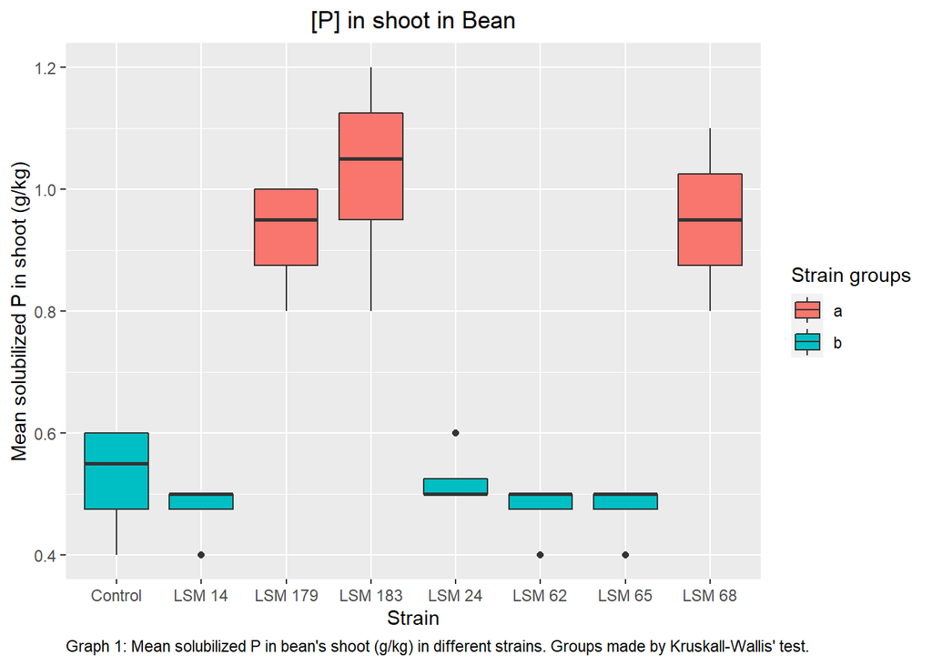

```r
Bplot_Pshoot <- ggplot(D_Bean, aes(x=`Treatments (strains)`, y=`P Shoot g/kg`, fill=kruskalbean8$groups[`Treatments (strains)`, "groups"])) +
  geom_boxplot()+
  labs(fill = "Strain groups")+
  xlab('Strain') +
  ylab('Mean solubilized P in shoot (g/kg)')+
  labs(title = "[P] in shoot in Bean",
    caption= "Graph 1: Mean solubilized P in bean's shoot (g/kg) in different strains. Groups made by Kruskall-Wallis' test. ")+
  theme(plot.title = element_text(hjust = 0.5),
        plot.caption = element_text(hjust = 0))
Bplot_Pshoot
```

[figure not shown]

```r
Bplot_Proot <- ggplot(D_Bean, aes(x=`Treatments (strains)`, y=`P Roots g/kg`, fill=kruskalbean9$groups[`Treatments (strains)`, "groups"])) +
  geom_boxplot()+
  labs(fill = "Strain groups") +
  xlab('Strain') +
  ylab('Mean solubilized P in shoot (g/kg)')+
  labs(title = "[P] in root in Bean",
         caption= "Graph 2: Mean solubilized P in bean's root (g/kg) in different strains. Groups made by Kruskall-Wallis' test. ")+
  theme(plot.title = element_text(hjust = 0.5),
        plot.caption = element_text(hjust = 0))
Bplot_Proot
```

### Maize

```r
strain.maize <-  c("LSM_65","LSM_65","Control","Control/LSM_65", "LSM_24", "LSM_24", "Control/LSM_65/LSM_14/LSM_24/LSM_62", "NA","LSM_65/LSM_24")
posthoc.maize <-  c("Duncan","Duncan","Duncan","Duncan","Kruskal-Wallis","Kruskal-Wallis","Kruskal-Wallis", "Not significant", "Duncan" )
var.name.maize <- c("Plant Height", "Shoot dry mass","Root dry mass", "Total dry mass", "P soil", "P shoot", "P root","N shoot", "N root" )
maize.name <-  c(rep("Maize", 9))
maize.groups <- c("a, ab, bc, bc, cd, cd, de, e","a, ab, ab, ab, abc, bc, bc, c","a, ab, abc, abc, bc, bc, c, c","a, a, ab, ab, abc, bc, bc, c","a, ab, abc, abc, abc, bc, bc, bc, c", "a, ab, ab, bc, bc, c, c, c", "a, a, a, a, a, b, b, b", "a, a, a, a, a, a, a, a", "a,a,ab,ab,ab,ab,bc,c")
data.strains.maize <-  data.frame(maize.name, var.name.maize, posthoc.maize,maize.groups, strain.maize)

data.strains.maize <- data.strains.maize %>%
  rename("Crop" = maize.name,
          "Variable" = var.name.maize,
          "Post-hoc analysis" = posthoc.maize,
         "Groups"= maize.groups,
          "Optimal strain" = strain.maize)
MaizeTable <- kbl(data.strains.maize) %>%
  kable_styling(bootstrap_options = c("hover"))%>%
  column_spec(1, bold = T) %>%
  column_spec(c(1:4), border_left = FALSE, border_right = FALSE) %>%
  collapse_rows(columns = 1:2, valign = "middle") %>%
  footnote(general = "*Table 3*: Optimal strains for each variable measured in maize greenhouse experiments adressed by Kruskal-Wallis or Duncan analysis when significant differences are found. NA: Not applicable.", general_title = "")

MaizeTable
```

[output not shown]

*Table 3*: Optimal strains for each variable measured in maize greenhouse experiments adressed by Kruskal-Wallis or Duncan analysis when significant differences are found. NA: Not applicable.

In this case, it is visible that the parameters are mainly affected by 2 strains. Strain LSM 65 has a positive effect in the growth-related variables, whereas strain LSM 24 is the best performer for the biochemical traits like P solubilization.

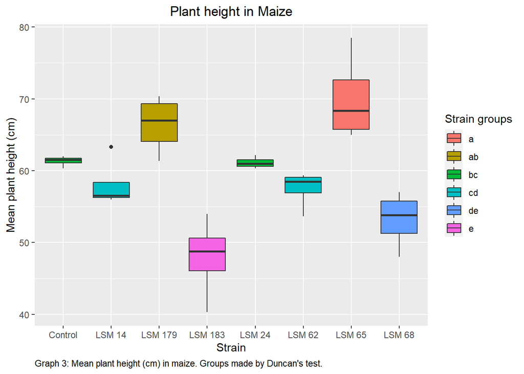

```r
Mplot_Height <- ggplot(D_Maize, aes(x=`Treatments (strains)`, y=`Plant high (Mean - cm)`, fill=Duncan.Maize3$groups[`Treatments (strains)`, "groups"])) +
  geom_boxplot()+
  labs(fill = "Strain groups") +
  xlab('Strain') +
  ylab('Mean plant height (cm)')+
  labs(title = "Plant height in Maize",
    caption= "Graph 3: Mean plant height (cm) in maize. Groups made by Duncan's test.")+
  theme(plot.title = element_text(hjust = 0.5),
        plot.caption = element_text(hjust = 0))

Mplot_Height
```

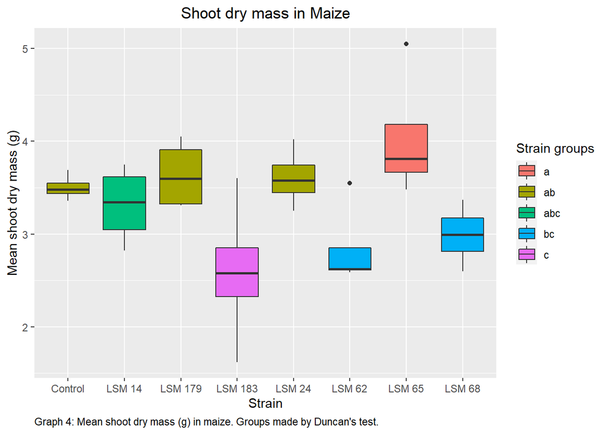

```r
Mplot_Shootmass <- ggplot(D_Maize, aes(x=`Treatments (strains)`, y= `Shoot dry mass (g)`,fill=Duncan.Maize4$groups[`Treatments (strains)`, "groups"] )) +
  geom_boxplot()+
  labs(fill = "Strain groups") +
  xlab('Strain') +
  ylab('Mean shoot dry mass (g)')+
  labs(title = "Shoot dry mass in Maize",
    caption= "Graph 4: Mean shoot dry mass (g) in maize. Groups made by Duncan's test.")+
  theme(plot.title = element_text(hjust = 0.5),
        plot.caption = element_text(hjust = 0))
Mplot_Shootmass
```

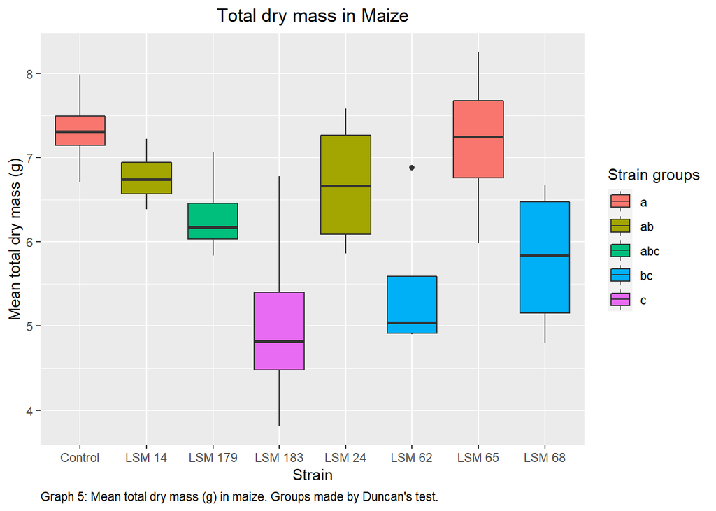

```r
Mplot_Totalmass <- ggplot(D_Maize, aes(x=`Treatments (strains)`, y=`Total dry mass (g)`,fill=Duncan.Maize6$groups[`Treatments (strains)`, "groups"] )) +
  geom_boxplot()+
  labs(fill = "Strain groups") +
  xlab('Strain') +
  ylab('Mean total dry mass (g)')+
  labs(title = "Total dry mass in Maize",
    caption= "Graph 5: Mean total dry mass (g) in maize. Groups made by Duncan's test.")+
  theme(plot.title = element_text(hjust = 0.5),
        plot.caption = element_text(hjust = 0))
Mplot_Totalmass
```

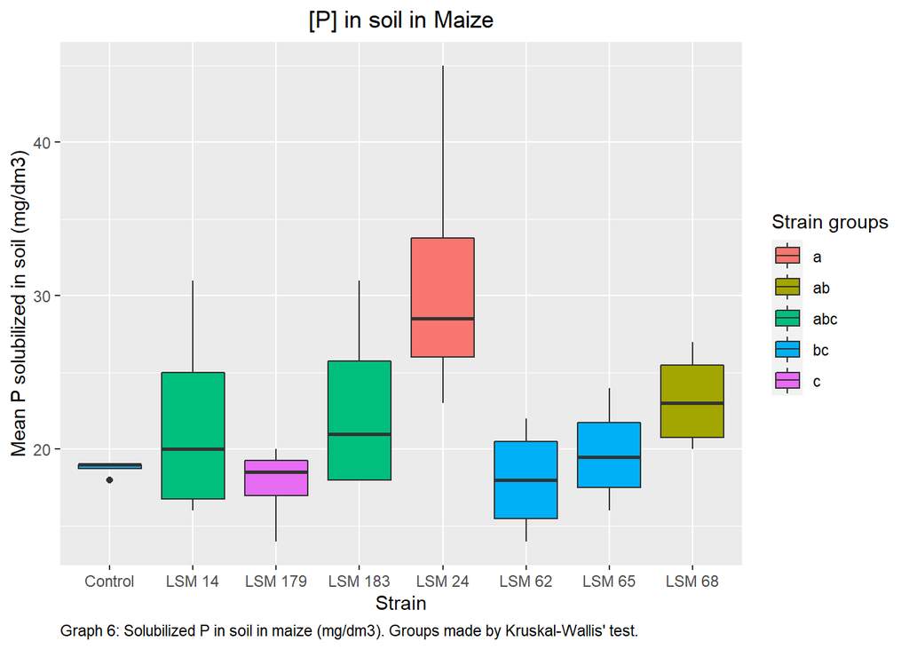

```r
Mplot_Psoil <- ggplot(D_Maize, aes(x=`Treatments (strains)`, y=`P Soil (mg/dm3)`, fill=kruskalmaize7$groups[`Treatments (strains)`, "groups"])) +
  geom_boxplot()+
  labs(fill = "Strain groups") +
  xlab('Strain') +
  ylab('Mean P solubilized in soil (mg/dm3)')+
  labs(title = "[P] in soil in Maize",
    caption= "Graph 6: Solubilized P in soil in maize (mg/dm3). Groups made by Kruskal-Wallis' test.")+
  theme(plot.title = element_text(hjust = 0.5),
        plot.caption = element_text(hjust = 0))
Mplot_Psoil
```

[figure not shown]

```r
Mplot_Pshoot <- ggplot(D_Maize, aes(x=`Treatments (strains)`, y=`P Shoot g/kg`, fill=kruskalmaize8$groups[`Treatments (strains)`, "groups"])) +
  geom_boxplot()+
  labs(fill = "Strain groups") +
  xlab('Strain') +
  ylab('Mean P solubilized in shoot (mg/dm3)')+
  labs(title = "[P] in shoot in Maize",
    caption= "Graph 7: Solubilized P in shoot in maize (mg/dm3). Groups made by Kruskal-Wallis' test.")+
  theme(plot.title = element_text(hjust = 0.5),
        plot.caption = element_text(hjust = 0))
Mplot_Pshoot
```

[figure not shown]

```r
Mplot_Nroot <- ggplot(D_Maize, aes(x=`Treatments (strains)`, y= `N Roots g/kg`, fill=Duncan.Maize11$groups[`Treatments (strains)`, "groups"] )) +
  geom_boxplot()+
  labs(fill = "Strain groups") +
  xlab('Strain') +
  ylab('Mean N in roots (g/kg)')+
  labs(title = "N in root in Maize",
    caption= "Graph 8: N concentration in root in maize (mg/dm3). Groups made by Duncan's test.")+
  theme(plot.title = element_text(hjust = 0.5),
        plot.caption = element_text(hjust = 0))
Mplot_Nroot
```

### Soybean

```r
strain.soy <- c("LSM_179", "NA", "NA",  "NA", "All", "LSM_14/LSM_24/LSM_62", "LSM_183/LSM_179", "NA","NA")
posthoc.soy <- c("Duncan", "Duncan", "Duncan", "Duncan","Kruskal-Wallis","Kruskal-Wallis","Kruskal-Wallis", "Duncan", "Duncan" )
var.name.soy <- c("Plant Height",  "Shoot dry mass","Root dry mass",  "Total dry mass",  "P soil", "P shoot", "P root","N shoot",  "N root" )
soy.name <-  c(rep("Soybean", 9))
soy.groups <- c("a, ab, ab, abc, abc, bc, bc, c", "a, a, a, a, a, a, a, a", "a, a, a, a, a, a, a, a", "a, a, a, a, a, a, a, a", "a, a, a, a, a, a, a, a", "a, a, a, ab, ab, ab, ab, b", "a, a, ab, ab, ab, ab, ab, b", "a, a, a, a, a, a, a, a", "a, a, a, a, a, a, a, a")
data.strains.soy <-  data.frame(soy.name, var.name.soy, posthoc.soy, soy.groups, strain.soy)

data.strains.soy <- data.strains.soy %>%
  rename("Crop" = soy.name,
         "Variable" = var.name.soy,
         "Post-hoc analysis" = posthoc.soy,
         "Optimal strain" = strain.soy)
SoybeanTable <- kbl(data.strains.soy) %>%
  kable_styling(bootstrap_options = c("hover"))%>%
  column_spec(1, bold = T) %>%
  column_spec(c(1:4), border_left = FALSE, border_right = FALSE) %>%
  collapse_rows(columns = 1:2, valign = "middle") %>%
  footnote(general = "*Table 4*: Optimal strains for each variable measured in soybean greenhouse experiments adressed by Kruskal-Wallis, or Duncan analysis when significant differences are found. NA: Not applicable.", general_title = "")

SoybeanTable
```

| Crop | Variable | Post-hoc analysis | soy.groups | Optimal strain |
| --- | --- | --- | --- | --- |
| Soybean | Plant Height | Duncan | a, ab, ab, abc, abc, bc, bc, c | LSM_179 |
|  | Shoot dry mass | Duncan | a, a, a, a, a, a, a, a | NA |
|  | Root dry mass | Duncan | a, a, a, a, a, a, a, a | NA |
|  | Total dry mass | Duncan | a, a, a, a, a, a, a, a | NA |
|  | P soil | Kruskal-Wallis | a, a, a, a, a, a, a, a | All |
|  | P shoot | Kruskal-Wallis | a, a, a, ab, ab, ab, ab, b | LSM_14/LSM_24/LSM_62 |
|  | P root | Kruskal-Wallis | a, a, ab, ab, ab, ab, ab, b | LSM_183/LSM_179 |
|  | N shoot | Duncan | a, a, a, a, a, a, a, a | NA |
|  | N root | Duncan | a, a, a, a, a, a, a, a | NA |

*Table 4*: Optimal strains for each variable measured in soybean greenhouse experiments adressed by Kruskal-Wallis, or Duncan analysis when significant differences are found. NA: Not applicable.

Last, the experiments in soybean show how this plant is affected by LSM 179, 183, 14, 24 and 62, but only in 3 parameters. In the rest of them, no significant difference has been found.

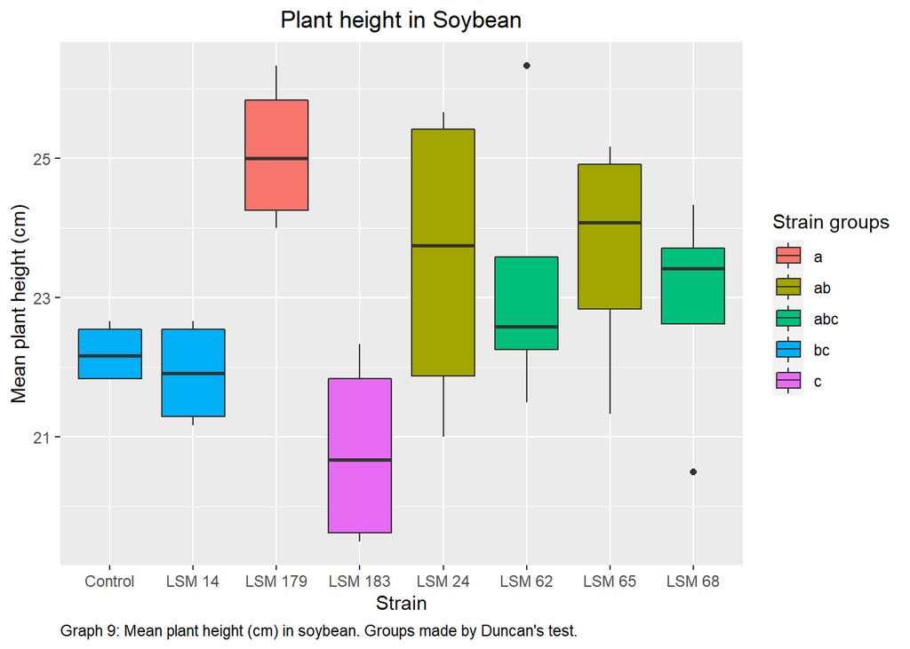

```r
Splot_Height <- ggplot(D_Soy, aes(x=`Treatments (strains)`, y=`Plant high (Mean - cm)`, fill=Duncan.Soy3$groups[`Treatments (strains)`, "groups"])) +
  geom_boxplot()+
  labs(fill = "Strain groups") +
  xlab('Strain') +
  ylab('Mean plant height (cm)')+
  labs(title = "Plant height in Soybean",
    caption= "Graph 9: Mean plant height (cm) in soybean. Groups made by Duncan's test.")+
  theme(plot.title = element_text(hjust = 0.5),
        plot.caption = element_text(hjust = 0))
Splot_Height
```

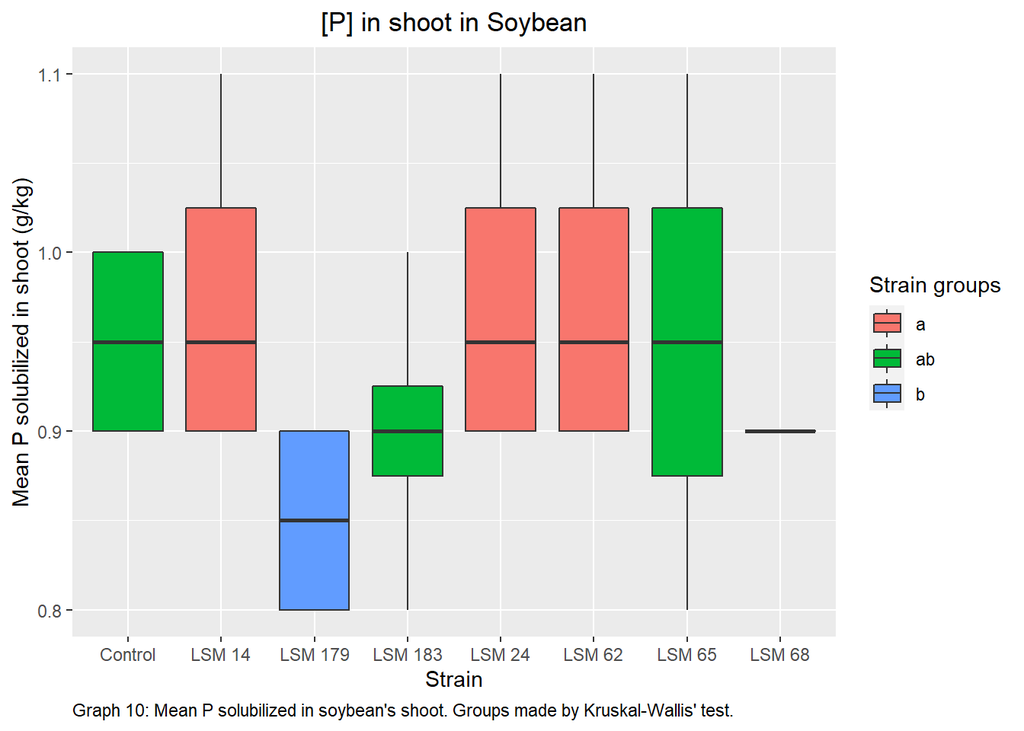

```r
Splot_Pshoot <- ggplot(D_Soy, aes(x=`Treatments (strains)`, y=`P Shoot g/kg`, fill=kruskalsoy8$groups[`Treatments (strains)`, "groups"])) +
  geom_boxplot()+
  labs(fill = "Strain groups") +
  xlab('Strain') +
  ylab('Mean P solubilized in shoot (g/kg)')+
  labs(title = "[P] in shoot in Soybean",
    caption= "Graph 10: Mean P solubilized in soybean's shoot. Groups made by Kruskal-Wallis' test.")+
  theme(plot.title = element_text(hjust = 0.5),
        plot.caption = element_text(hjust = 0))
Splot_Pshoot
```

[figure not shown]

```r
Splot_Proot <- ggplot(D_Soy, aes(x=`Treatments (strains)`, y=`P Roots g/kg`, fill=kruskalsoy9$groups[`Treatments (strains)`, "groups"])) +
  geom_boxplot()+
  labs(fill = "Strain groups") +
  xlab('Strain') +
  ylab('Mean P solubilized in shoot (g/kg)')+
  labs(title = "[P] in root in Soybean",
    caption= "Graph 11: Mean solubilized P in soybean's roots. Groups made by Kruskal-Wallis' test.")+
  theme(plot.title = element_text(hjust = 0.5),
        plot.caption = element_text(hjust = 0))
Splot_Proot
```